# Andrew Loeppky

## Assignment 2

## EOSC 510

## Question 1

**You'd like to analyze the given data (PCA.mat or PCA.csv) using principal component analysis (PCA). The dataset contains time series of four variables: x1, x2, x3 and x4, each containing 40 observations (points in time). You'd like to investigate whether you can decrease the number of dimensions (variables) in this dataset.**

### 1) Plot the time series for each variable at the same graph.

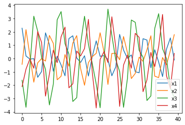

```python
data_in.plot();
```

### 2) Perform PCA on the data and plot the fraction of variance explained per mode.

```python
# do we need to remove the mean? (is it nonzero?)
```

```
0.155976295025
0.045619847775000014
-0.12247306799999999
-0.11447336909999999
```

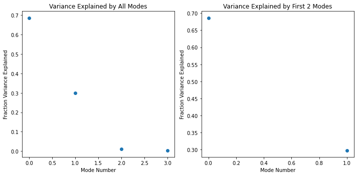

### 3) Determine how many modes you want to keep in order to reconstruct the data and provide a rationale for your selection.

```
Variance explained by first mode:     0.6864151020563097
Variance explained by first 2 modes:  0.9845742630650094
Variance explained by 3 modes:        0.9955916755152393
Variance explained by all modes:      0.9999999999999998
```

The first two modes explain 98\% of the variance, so I will keep 2 and throw away the second two. If I really wanted to preserve at least 99\% of the variance for some reason, I might keep the third

### 4) Plot the PCs of the significant modes (i.e. those that you decided to keep). Briefly discuss the results (e.g. are the PCs showing some trend, or oscillations or something else)

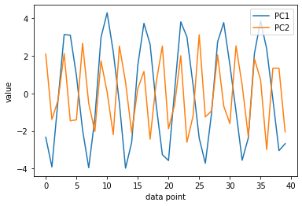

PC1 is periodic (sinusoidal? hard to tell with the sampling frequency this low) with a period of about 6 and an amplitude of 4

PC2 also appears to be periodic with a period of 3 and an amplitude of 2. Variance in the amplitude could easily be from the low sampling freq.

### 5) Plot PC1 vs PC2, i.e. plot the data in the space of the first two eigenvectors

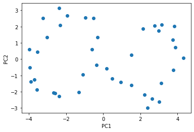

## Question 2

**You are given a dataset containing annual temperature timeseries (1951-2000) from 28 stations across Canada. Figure on the right shows average annual temperature over these 50 years for each station (plotted as a heat map). Data is given in Temp_data.csv (or Temp_data.mat where T contains temperature data -> 50 rows and 28 columns, Lat is latitude of each station, Lon is longitude of each station, and years is the array of years). You'd like to analyze characteristic spatial patterns of temperature data across these stations, and evolution of these spatial patterns in time. To do so, you apply PCA on the data.**

### 1) Plot the fraction of variance explained by each mode. How many modes would you decide to keep if you want these modes to explain in total >90% of variance in the dataset?

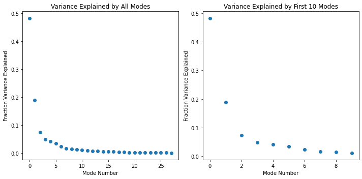

```
Variance explained by 1 modes : 0.4825410289624701
Variance explained by 2 modes : 0.6710921757691652
Variance explained by 3 modes : 0.7453135301343737
Variance explained by 4 modes : 0.7931347119532689
Variance explained by 5 modes : 0.835240325574515
Variance explained by 6 modes : 0.869979355133775
Variance explained by 7 modes : 0.8938949804200592
Variance explained by 8 modes : 0.9101891086232118
Variance explained by 9 modes : 0.9247590268092849
```

To preserve 90\% of the variance, I will need to keep 8 modes

### 2) For each of the first three modes: plots its spatial pattern (as a heat map) and its evolution in time.

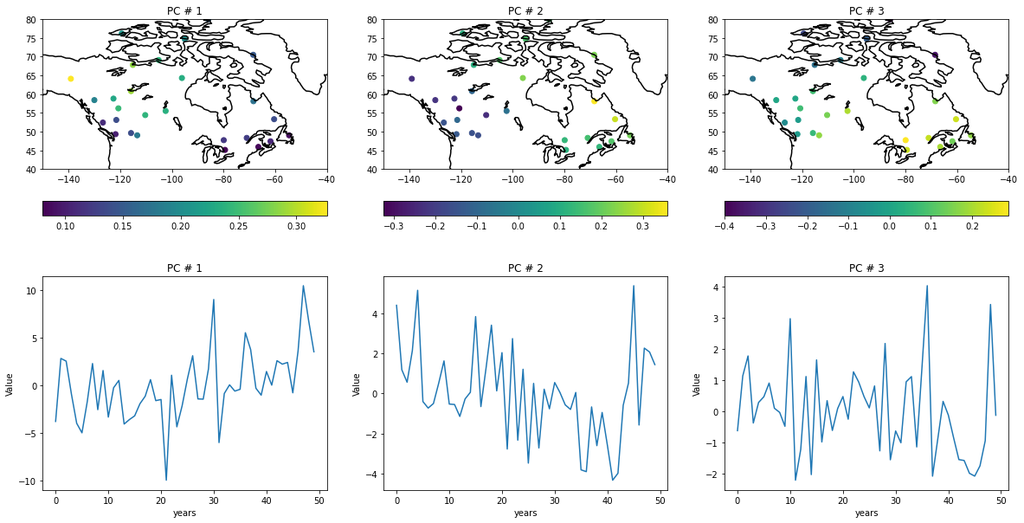

### 3) Focus on the results from the first mode only and answer the following:

**a) Describe briefly the spatial pattern (e.g. are there any spatial gradients and how are they oriented, for example are they oriented North-South or West-East or something else?)**

*PC1 looks to be high in the northwest and low in the southeast*

**b) Describe briefly the temporal pattern (e.g. is it revealing any long-term trends, decadal fluctuations, or anything else?)**

*PC1 steadily increases over time, with significant noise*

**c) What years was the spatial pattern most pronounced and what years was the opposite (flipped) spatial pattern most pronounced?**

```
PC1 was most pronounced in 1998, with a value of 10.48
PC1 was most 'flipped' in 1972, with a value of -9.99
```

### 4) Reconstruct the data from the first three modes (k=3). Plot the original and reconstructed timeseries for the following two stations: station #6 (lat=45.1, lon=-79.4) and station #26 (lat=64.1, lon=-139.1). Calculate the correlation coefficient between the original and reconstructed timeseries for each of these two stations. Based on the correlations, at which station of the two is the reconstruction better (i.e. better resembling the original data) and why is this so (why is the reconstitution better over one station than other)?

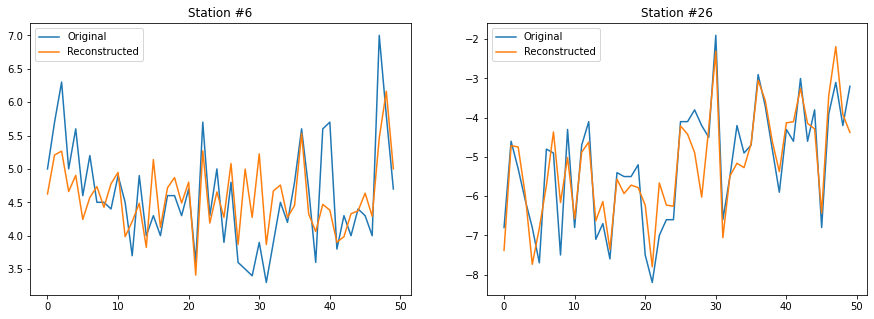

```
Correlation between measured and reconstructed at station 6:  0.6558019190167743
Correlation between measured and reconstructed at station 26: 0.8956740584905614
```

Based on the coefficients, the first 3 modes do a better job of reconstructing station 26 than station 6. Station 6 must therefore be subject to a greater influence from one of the other modes (4, 5, 6...) as compared with station 26